# subject_a.tumor LINX Reporter

https://github.com/umccr/linxreport

2025-07-07 00:03:26

## Tables

### Main

#### Annotations (4)

- additional annotations of each non PON filtered break junction
- `svs.tsv`

**Column Description**

| Field | Description |
| --- | --- |
| vcfId | ID of break junction for mapping to GRIDSS / PURPLE vcf |
| svId | ID of break junction |
| clusterId | ID of cluster which break junction is assigned to |
| clusterReason | Reason for clustering and svId of clustered break junction for other break junction(s) to which the variant has been clustered |
| fragileSiteStart | Start breakend of break junction is in a known fragile site (T/F) |
| fragileSiteEnd | End breakend of break junction is in a known fragile site (T/F) |
| isFoldback | Break junction is classified as a foldback (T/F) |
| lineTypeStart | Start breakend of break junction is in a known or suspected line source region |
| lineTypeEnd | End breakend of break junction is in a known or suspected line source region |
| junctionCopyNumberMin | Minimum bound JCN estimate for breakjunction |
| junctionCopyNumberMax | Maximum bound JCN estimate for breakjunction |
| geneStart | Gene(s) overlapping start breakend of SV |
| geneEnd | Gene(s) overlapping end breakend of SV |
| localTopologyIdStart | ID for group of proximate breakends to the start breakend of break junction within an extending 5kb window |
| localTopologyIdEnd | ID for group of proximate breakends to the end breakend of break junction within an extending 5kb window |
| localTopologyStart | Local breakend topology type at site of start breakend. [ISOLATED_BE, DSB, TI_ONLY, SIMPLE_DUP, FOLDBACK, FOLDBACK_DSB, SAME_ORIENT, COMPLEX_FOLDBACK, COMPLEX_LINE, COMPLEX_OTHER] |
| localTopologyEnd | Local breakend topology type at site of end breakend. [ISOLATED_BE, DSB, TI_ONLY, SIMPLE_DUP, FOLDBACK, FOLDBACK_DSB, SAME_ORIENT, COMPLEX_FOLDBACK, COMPLEX_LINE, COMPLEX_OTHER] |
| localTICountStart | Number of chained templated insertions in local topology group of start breakend |
| localTICountEnd | Number of chained templated insertions in local topology group of end breakend |

| vcfId | svId | clusterId | geneStart | geneEnd | clusterReason | fragileSiteStart | fragileSiteEnd | isFoldback | lineTypeStart | lineTypeEnd | junctionCopyNumberMin | junctionCopyNumberMax | localTopologyIdStart | localTopologyIdEnd | localTopologyStart | localTopologyEnd | localTICountStart | localTICountEnd |
| --- | --- | --- | --- | --- | --- | --- | --- | --- | --- | --- | --- | --- | --- | --- | --- | --- | --- | --- |
| 0 | 0 | 1 | MLLT3;RNU4-26P | KMT2A | PROXIMITY-1 | false | false | false | NONE | NONE | 0.1398 | 1.8327 | 0 | 1 | DSB | DSB | 0 | 0 |
| 1 | 1 | 1 | MLLT3;MIR4473;RNU4-26P | KMT2A | PROXIMITY-0 | false | false | false | NONE | NONE | 0.1412 | 1.8346 | 0 | 1 | DSB | DSB | 0 | 0 |
| 4 | 2 | 0 | CCNE1 |  | PROXIMITY-3 | false | false | false | NONE | NONE | -0.3092 | 1.5506 | 0 | -1 | DSB |  | 0 | 0 |
| 5 | 3 | 0 | CCNE1 |  | PROXIMITY-2 | false | false | false | NONE | NONE | -0.0272 | 1.8848 | 0 | -1 | DSB |  | 0 | 0 |

#### Breakends (20)

- impact of each non PON filtered break junction on each overlapping gene
- `breakend.tsv`

**Column Description**

| Field | Description |
| --- | --- |
| id | Id of breakend annotation |
| svId | Id of break junction |
| isStart | Annotation relates to the start breakend of the break junction (1 = true,0 = false) |
| gene | Gene annotated |
| transcriptId | Ensembl stable transcript id of annotation |
| canonical | Transcript is the canonical transcript of the gene. LINX annotates 1 record for each canonical transcript overlapping the breakend + a record for any non-canonical transcript that is annotated as part… |
| geneOrientation | Orientation which breakend points relative to the gene taking into account both gene strand and breakend orientation. |
| disruptive | Breakend is part of a break junction which disrupts the exonic sequence of the transcript |
| reportedDisruption | Breakend is disruptive and gene is flagged as reportable for disruption |
| undisruptedCopyNumber | Number of remaining wildtype alleles of the gene that are not disrupted by the breakend. If <0.5 then disruption is considered Homozygous |
| regionType | Location of the breakend relative to the transcript. [UPSTREAM (within 100kb upstream of the 1st base of the transcript), INTRONIC, EXONIC] |
| codingType | Location of the breakend relative to the coding context of the transcript. [CODING, NON_CODING, UTR_5P, UTR_3P, ENHANCER (IG enhancer rearrangements only) |
| biotype | Ensembl biotype of the transcript |
| exonicBasePhase | If regionType = EXONIC, the exact base phase of the breakend, else -1 |
| nextSpliceExonRank | The exon rank of the next splice acceptor (if gene orientation is ‘DOWNSTREAM’) or splice donor (if gene orientation is ‘UPSTREAM’) |
| nextSpliceExonPhase | The phase of the 1st base after the next splice acceptor (if gene orientation is ‘DOWNSTREAM’) or splice donor (if gene orientation is ‘UPSTREAM’) |
| nextSpliceDistance | The distance in bases to the next splice site identified in nextSpliceExonRank |
| totalExonCount | Total number of exons in the transcript |
| exonUp | . |
| exonDown | . |

| id | svId | isStart | gene | transcriptId | canonical | geneOrientation | disruptive | reportedDisruption | undisruptedCopyNumber | regionType | codingType | biotype | exonicBasePhase | nextSpliceExonRank | nextSpliceExonPhase | nextSpliceDistance | totalExonCount | exonUp | exonDown |
| --- | --- | --- | --- | --- | --- | --- | --- | --- | --- | --- | --- | --- | --- | --- | --- | --- | --- | --- | --- |
| 0 | 0 | true | MLLT3 | ENST00000380338 | true | Downstream | true | false | 0.992 | INTRONIC | CODING | protein_coding | 0 | 5 | 0 | 1 | 11 | 4 | 5 |
| 1 | 0 | true | MIR4473 | ENST00000583731 | true | Downstream | false | false | 0.992 | UPSTREAM | NON_CODING | miRNA | -1 | 1 | -1 | 3188 | 1 | 0 | 1 |
| 2 | 0 | true | RNU4-26P | ENST00000410270 | true | Upstream | false | false | 0.992 | UPSTREAM | NON_CODING | snRNA | -1 | 0 | -1 | -1 | 1 | 0 | 1 |
| 3 | 0 | false | KMT2A | ENST00000534358 | true | Upstream | true | false | 1.042 | EXONIC | CODING | protein_coding | 0 | 9 | 0 | 112 | 36 | 10 | 10 |
| 4 | 0 | false | TTC36 | ENST00000302783 | true | Upstream | false | false | 1.042 | UPSTREAM | CODING | protein_coding | 1 | 0 | 1 | -36923 | 3 | 0 | 2 |
| 5 | 0 | false | TMEM25 | ENST00000313236 | true | Upstream | false | false | 1.042 | UPSTREAM | UTR_5P | protein_coding | -1 | 0 | -1 | -45680 | 9 | 0 | 2 |
| 6 | 0 | false | RPL5P30 | ENST00000465511 | true | Upstream | false | false | 1.042 | UPSTREAM | NON_CODING | processed_pseudogene | -1 | 0 | -1 | -61145 | 1 | 0 | 1 |
| 7 | 0 | false | ARCN1 | ENST00000264028 | true | Upstream | false | false | 1.042 | UPSTREAM | CODING | protein_coding | 0 | 0 | 0 | -61145 | 10 | 0 | 2 |
| 8 | 1 | true | MLLT3 | ENST00000380338 | true | Upstream | true | false | 0.99 | INTRONIC | CODING | protein_coding | 0 | 4 | 0 | 33122 | 11 | 4 | 5 |
| 9 | 1 | true | MIR4473 | ENST00000583731 | true | Upstream | false | false | 0.99 | UPSTREAM | NON_CODING | miRNA | -1 | 0 | -1 | -576 | 1 | 0 | 1 |

[output cut: 10 more lines]

#### Clusters (2)

- clustering of all non PON filtered SV events and their resolved classification.
- `clusters.tsv`

**Column Description**

| Field | Description |
| --- | --- |
| clusterId | Unique Id for the cluster |
| category | High level categorisation of the cluster classification |
| synthetic | Set to TRUE if the cluster is resolved to a non complex type by simplification of a short templated insertion (<1kb) |
| resolvedType | Resolved classification of the cluster. |
| clusterCount | The number of break junctions in the cluster |
| clusterDesc | String containing the types and counts of break junctions in the cluster. eg. DEL=2_INV=2 |

| clusterId | category | synthetic | resolvedType | clusterCount | clusterDesc |
| --- | --- | --- | --- | --- | --- |
| 0 | SIMPLE | false | SGL_PAIR_INS | 2 | SGL=2 |
| 1 | RECIPROCAL | false | RECIP_TRANS | 2 | BND=2 |

#### Links (0)

- segments joining break junction pairs predicted to be linked and phased in *cis* on the derivative chromosome.
- `links.tsv`

**Column Description**

| Field | Description |
| --- | --- |
| clusterId | Id of the cluster which contains the link |
| chainId | Id of the chain to which the link belongs representing a multi-segment prediction of the derivative chromosome |
| chainIndex | Position of the linked segment in the chain. The predicted chain can be reconstructed by traversing each linked segment in order ie. 0,1,…,n |
| chainCount | Total count of linked segments in the chan |
| lowerSvId | svId of the leftmost breakend of the linked segment |
| upperSvId | svId of the rightmost breakend of the linked segment |
| lowerBreakendIsStart | True if the lower breakend is the start breakend of the break junction |
| upperBreakendIsStart | True if the right breakend is the start breakend of the break junction |
| chromosome | Chromosome of the linked segment |
| arm | Arm (P/Q) of the linked segment |
| assembled | True if the segment is linked by a GRIDSS assembly |
| traversedSVCount | The number of other breakends that are located on the linked segment |
| length | Length of the linked segment |
| junctionCopyNumber | Predicted copy number of the chain |
| junctionCopyNumberUncertainty | Uncertainty in the copy number of the chain |
| pseudogeneInfo | If the segment precisely matches an exon of an ensembl gene, then contains details of the matching exon: {geneName;TranscriptId,ExonRank,ExonLength} |
| ecDna | True if the link is predicted to be part of a DM / ecDNA chain |

| clusterId | chainId | chainIndex | chainCount | lowerSvId | upperSvId | lowerBreakendIsStart | upperBreakendIsStart | chromosome | arm | assembled | traversedSVCount | length | junctionCopyNumber | junctionCopyNumberUncertainty | pseudogeneInfo | ecDna |
| --- | --- | --- | --- | --- | --- | --- | --- | --- | --- | --- | --- | --- | --- | --- | --- | --- |

#### Fusions (2)

- All inframe and outframe fusions predicted in the sample including HMF fusion knowledgebase annotations.
- `fusion.tsv`

**Column Description**

| Field | Description |
| --- | --- |
| fivePrimeBreakendId | Id of the 5’ breakend in the fusion |
| threePrimeBreakendId | Id of the 3’ breakend in the fusion |
| name | Name of the fusion in the form 5’GENE_3’GENE |
| reported | True if the fusion meets all reportable fusion criteria for LINX |
| reportedType | If one or both of the genes matches a promiscuous gene or known rearrangement in the HMF fusion knowledgebase, then the type of reportable gene pair: [KNOWN_PAIR, PROMISCUOUS_5, PROMISCUOUS_3, PROMISC… |
| reportableReasons | Reasons for given reportable status |
| phased | Set to 1 if a phased fusion can be formed (after allowing for exon skipping) |
| likelihood | . |
| chainLength | 0 for simple fusions. If fusion is chained equal to the total length of segments chained between 5’ and 3’ partners |
| chainLinks | 0 for simple fusions. If fusion is chained equal to the number of segments chained between 5’ and 3’ partners |
| chainTerminated | True if the fusion is interrupted either on the 5’ partner side by a chained breakend prior to the start of the 5’ gene or by a chained breakend prior to the last coding base of the 3’ gene |
| domainsKept | List of 3’ partner domains retained in fusion product (as annotated by PROSITE profiles) |
| domainsLost | List of 3’ partner domains lost in fusion product (as annotated by PROSITE profiles) |
| skippedExonsUp | Count of splice donors required to be skipped on 5’ partner side to form an inframe fusion. |
| skippedExonsDown | Count of splice donors required to be skipped on 3’ partner side to form an inframe fusion |
| fusedExonUp | Last exon fused on 5’ partner side |
| fusedExonDown | First exon fused on 3’ partner side |
| geneStart | . |
| geneContextStart | . |
| transcriptStart | . |
| geneEnd | . |
| geneContextEnd | . |
| transcriptEnd | . |
| junctionCopyNumber | . |

| fivePrimeBreakendId | threePrimeBreakendId | name | reported | reportedType | reportableReasons | phased | likelihood | chainLength | chainLinks | chainTerminated | domainsKept | domainsLost | skippedExonsUp | skippedExonsDown | fusedExonUp | fusedExonDown | geneStart | geneContextStart | transcriptStart | geneEnd | geneContextEnd | transcriptEnd | junctionCopyNumber |
| --- | --- | --- | --- | --- | --- | --- | --- | --- | --- | --- | --- | --- | --- | --- | --- | --- | --- | --- | --- | --- | --- | --- | --- |
| 8 | 11 | MLLT3_KMT2A | false | NONE | NOT_KNOWN | INFRAME |  | 0 | 0 | false |  |  | 0 | 0 | 4 | 11 | MLLT3 | Exon 4 | ENST00000380338 | KMT2A | Exon 11 | ENST00000534358 | 0.9879 |
| 3 | 0 | KMT2A_MLLT3 | true | KNOWN_PAIR | OK | INFRAME | HIGH | 0 | 0 | false |  | YEATS | 0 | 0 | 9 | 5 | KMT2A | Exon 9 | ENST00000534358 | MLLT3 | Exon 5 | ENST00000380338 | 0.9863 |

#### Driver Catalog (1)

- Reproduction of the driver catalog produced by PURPLE with homozygous disruption events appended.
- `driver.catalog.tsv`

**Column Description**

| Field | Description |
| --- | --- |
| chromosome | Chromosome of gene |
| chromosomeBand | Chromosome band of driver |
| gene | Gene name |
| transcript | Transcript name |
| isCanonical | Is canonical |
| driver | Driver type [AMP, DEL, MUTATION] |
| category | Gene driver type [ONCO, TSG] |
| likelihoodMethod | Method used to determine likelihood [AMP, DEL, BIALLELIC, DNDS, HOTSPOT, INFRAME] |
| driverLikelihood | Likelihood that gene is a driver |
| missense | Number of missense variants in gene |
| nonsense | Number of nonsense variants in gene |
| splice | Number of splice variants in gene |
| inframe | Number of inframe variants in gene |
| frameshift | Number of frameshift variants in gene |
| biallelic | True if any variants in the gene are biallelic |
| minCopyNumber | Minimum copy number found in the gene exons |
| maxCopyNumber | Maximum copy number found in the gene exons |

| chromosome | chromosomeBand | gene | transcript | isCanonical | driver | category | likelihoodMethod | driverLikelihood | missense | nonsense | splice | inframe | frameshift | biallelic | minCopyNumber | maxCopyNumber |
| --- | --- | --- | --- | --- | --- | --- | --- | --- | --- | --- | --- | --- | --- | --- | --- | --- |
| chr12 | p12.1 | KRAS | ENST00000311936 | true | MUTATION | ONCO | HOTSPOT | 1 | 1 | 0 | 0 | 0 | 0 | false | 1.9715 | 1.9715 |

#### Drivers (0)

- Linkage of drivers from driver catalog to SV cluster which contributed to those drivers including LOH, deletion, disruption and amplification events.
- `drivers.tsv`

**Column Description**

| Field | Description |
| --- | --- |
| clusterId | Id of cluster which break junction associated with driver. Set to -1 for ARM or CHR level events. |
| gene | Gene of driver. Multiple clusters may be linked to a gene for a sample |
| eventType | Type of driver. [GAIN (amplification by SV), GAIN_ARM (amplification of whole arm), GAIN_CHR (amplification of whole chromosome), DEL (homozygous deletion), LOH (focal LOH), LOH_ARM (arm level LOH), L… |

| clusterId | gene | eventType |
| --- | --- | --- |

### Vis

#### Copy Number (51)

- `vis_copy_number.tsv`

| Chrom | Start | End | CN | BAF |
| --- | --- | --- | --- | --- |
| 1 | 1 | 123605522 | 1.9764 | 0.5 |
| 1 | 123605523 | 248956422 | 1.9816 | 0.5037 |
| 2 | 1 | 93139350 | 2.0432 | 0.5108 |
| 2 | 93139351 | 242193529 | 2.0248 | 0.5061 |
| 3 | 1 | 92214015 | 2.0143 | 0.5035 |
| 3 | 92214016 | 198295559 | 2.008 | 0.507 |
| 4 | 1 | 50726025 | 2.0903 | 0.5216 |
| 4 | 50726026 | 190214555 | 2.0191 | 0.5047 |
| 5 | 1 | 48272853 | 1.9951 | 0.5073 |
| 5 | 48272854 | 181538259 | 1.9661 | 0.5086 |

[output cut: 41 more lines]

#### Fusion (1)

- `vis_fusion.tsv`

| ClusterId | Reportable | GeneNameUp | TranscriptUp | ChrUp | PosUp | StrandUp | RegionTypeUp | FusedExonUp | GeneNameDown | TranscriptDown | ChrDown | PosDown | StrandDown | RegionTypeDown | FusedExonDown |
| --- | --- | --- | --- | --- | --- | --- | --- | --- | --- | --- | --- | --- | --- | --- | --- |
| 1 | true | KMT2A | ENST00000534358 | chr11 | 118484974 | 1 | EXONIC | 9 | MLLT3 | ENST00000380338 | chr9 | 20414426 | -1 | INTRONIC | 5 |

#### Gene Exon (47)

- `vis_gene_exon.tsv`

| ClusterId | Gene | Transcript | Chrom | AnnotationType | ExonRank | ExonStart | ExonEnd |
| --- | --- | --- | --- | --- | --- | --- | --- |
| 1 | KMT2A | ENST00000534358 | 11 | FUSION | 1 | 118436492 | 118436944 |
| 1 | KMT2A | ENST00000534358 | 11 | FUSION | 2 | 118468775 | 118468844 |
| 1 | KMT2A | ENST00000534358 | 11 | FUSION | 3 | 118471662 | 118474315 |
| 1 | KMT2A | ENST00000534358 | 11 | FUSION | 4 | 118476805 | 118476982 |
| 1 | KMT2A | ENST00000534358 | 11 | FUSION | 5 | 118477967 | 118478201 |
| 1 | KMT2A | ENST00000534358 | 11 | FUSION | 6 | 118480174 | 118480238 |
| 1 | KMT2A | ENST00000534358 | 11 | FUSION | 7 | 118481715 | 118482092 |
| 1 | KMT2A | ENST00000534358 | 11 | FUSION | 8 | 118482422 | 118482495 |
| 1 | KMT2A | ENST00000534358 | 11 | FUSION | 9 | 118484183 | 118484314 |
| 1 | KMT2A | ENST00000534358 | 11 | FUSION | 10 | 118484862 | 118484975 |

[output cut: 37 more lines]

#### Protein Domain (15)

- `vis_protein_domain.tsv`

| ClusterId | Transcript | Chrom | Start | End | Info |
| --- | --- | --- | --- | --- | --- |
| 1 | ENST00000534358 | 11 | 118436492 | 118436512 | 5-Prime UTR |
| 1 | ENST00000534358 | 11 | 118478078 | 118480195 | ZF_CXXC |
| 1 | ENST00000534358 | 11 | 118484946 | 118488738 | ZF_PHD_2 |
| 1 | ENST00000534358 | 11 | 118488729 | 118490165 | ZF_PHD_2 |
| 1 | ENST00000534358 | 11 | 118491211 | 118491829 | ZF_PHD_2 |
| 1 | ENST00000534358 | 11 | 118493186 | 118494379 | BROMODOMAIN_2 |
| 1 | ENST00000534358 | 11 | 118496342 | 118499307 | EPHD |
| 1 | ENST00000534358 | 11 | 118499842 | 118501084 | FYRN |
| 1 | ENST00000534358 | 11 | 118510084 | 118519753 | FYRC |
| 1 | ENST00000534358 | 11 | 118521305 | 118522133 | SET |

[output cut: 5 more lines]

#### Segments (6)

- `vis_segments.tsv`

| ClusterId | ChainId | Chromosome | PosStart | PosEnd | LinkPloidy | InDoubleMinute |
| --- | --- | --- | --- | --- | --- | --- |
| 0 | 1 | 19 | C | 29815664 | 0.6207 | false |
| 0 | 2 | 19 | 29815665 | T | 0.9288 | false |
| 1 | 1 | 11 | C | 118484974 | 0.9863 | false |
| 1 | 1 | 9 | T | 20414426 | 0.9863 | false |
| 1 | 2 | 11 | 118485001 | T | 0.9879 | false |
| 1 | 2 | 9 | 20415001 | C | 0.9879 | false |

#### SV Data (4)

- `vis_sv_data.tsv`

| ClusterId | ChrStart | ChrEnd | PosStart | PosEnd | ChainId | SvId | Type | ResolvedType | IsSynthetic | OrientStart | OrientEnd | InfoStart | InfoEnd | JunctionCopyNumber | InDoubleMinute |
| --- | --- | --- | --- | --- | --- | --- | --- | --- | --- | --- | --- | --- | --- | --- | --- |
| 0 | chr19 | -1 | 29815664 | 0 | 1 | 2 | SGL | SGL_PAIR_INS | false | 1 | 0 | NORMAL |  | 0.6207 | false |
| 0 | chr19 | -1 | 29815665 | 0 | 2 | 3 | SGL | SGL_PAIR_INS | false | -1 | 0 | NORMAL |  | 0.9288 | false |
| 1 | chr9 | chr11 | 20414426 | 118484974 | 1 | 0 | BND | RECIP_TRANS | false | 1 | 1 | NORMAL | NORMAL | 0.9863 | false |
| 1 | chr9 | chr11 | 20415001 | 118485001 | 2 | 1 | BND | RECIP_TRANS | false | -1 | -1 | NORMAL | NORMAL | 0.9879 | false |

## Plots (Chromosome)

**Total:** 3 chromosome plots

### chr9

nsegs: 7

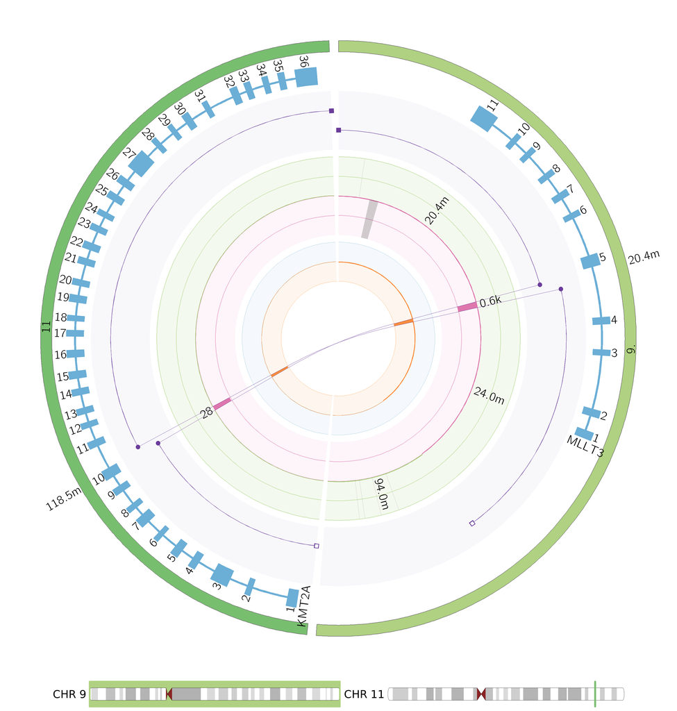

### chr11

nsegs: 7

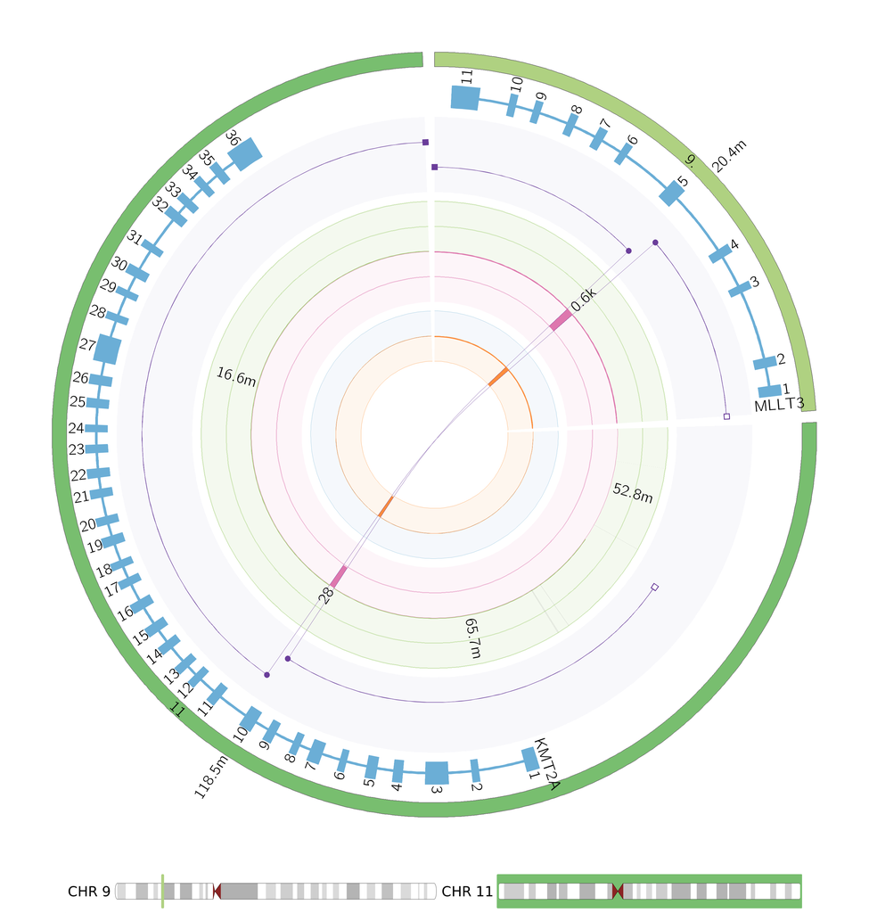

### chr19

nsegs: 0

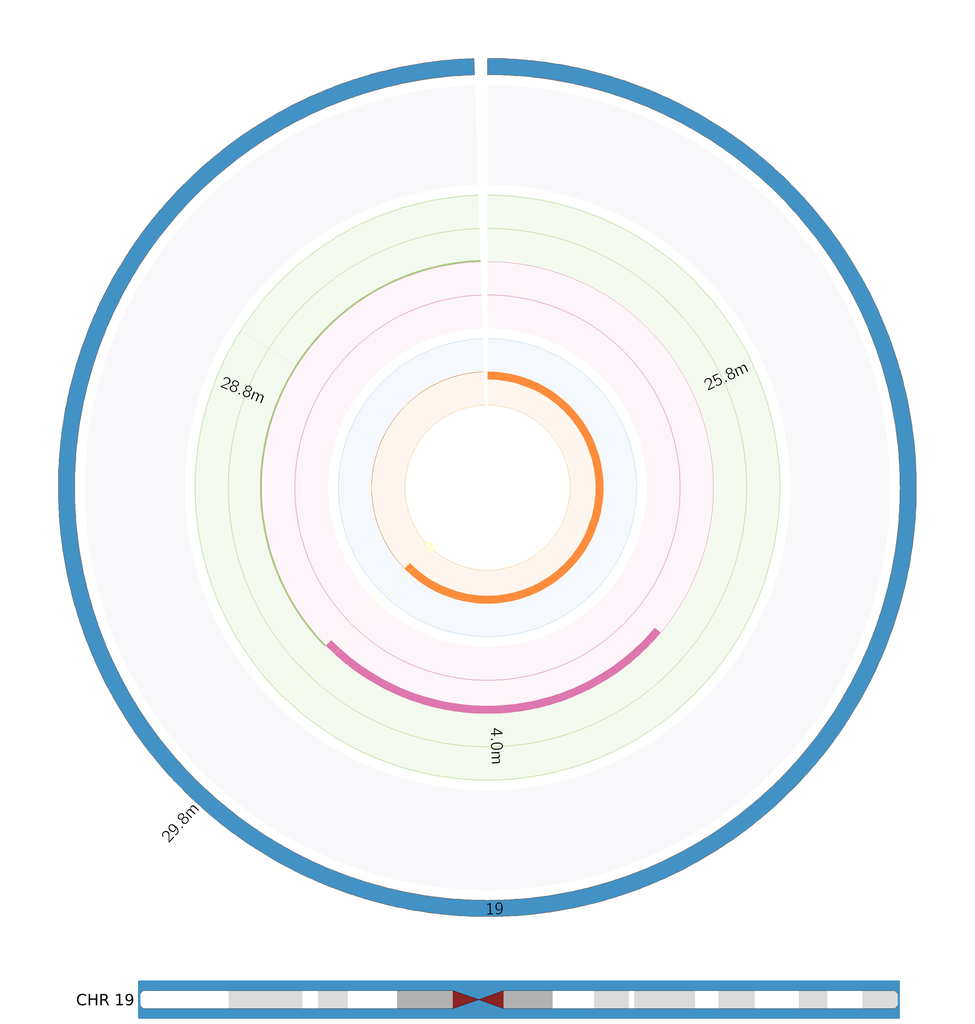

## Plots (Cluster)

**Total:** 2 cluster plots

### 0

clusterId: 0 | svId: 2 | nsegs: 3

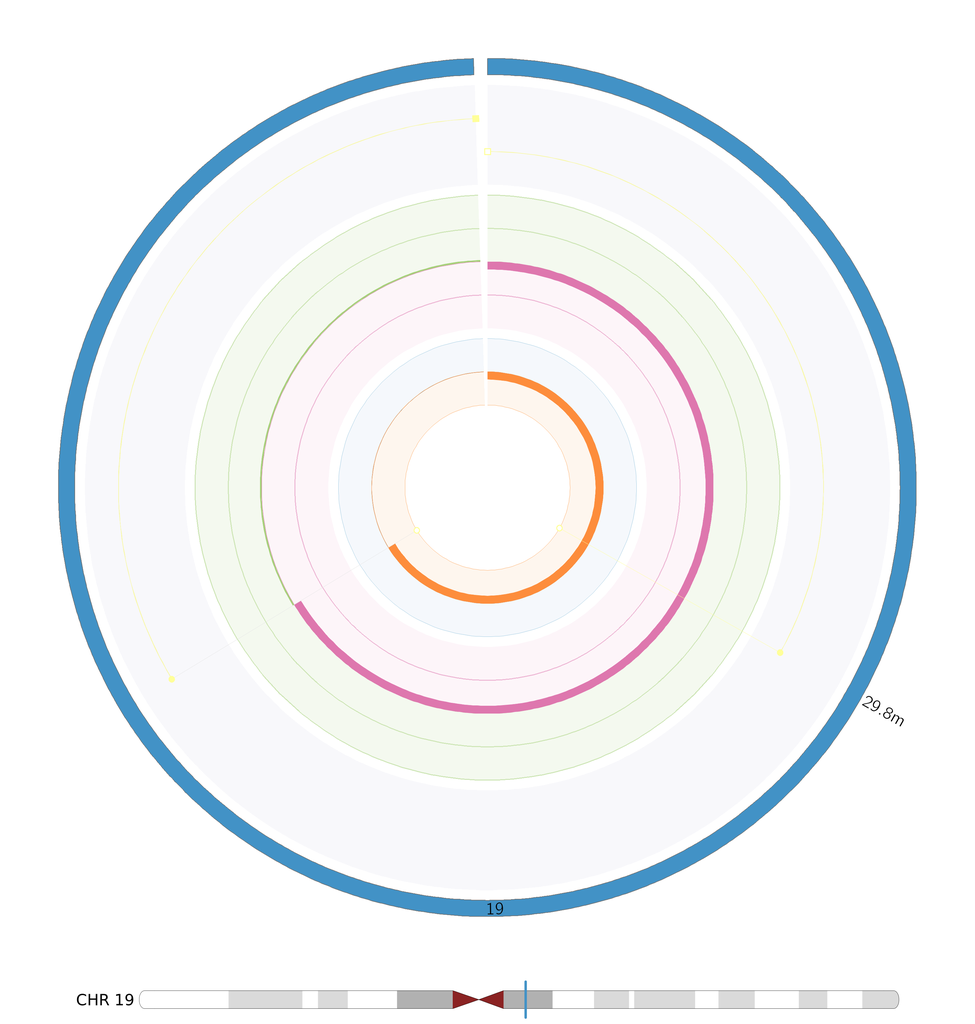

### 1

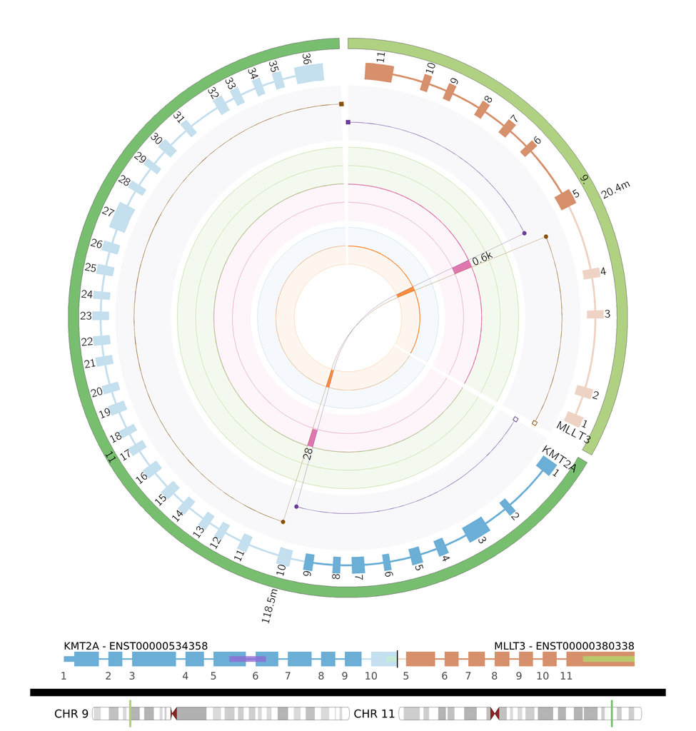

## Addendum

- `{linxreport}` documentation: https://umccr.github.io/linxreport/
- `{linxreport}` issues: https://github.com/umccr/linxreport/issues
- LINX documentation: https://github.com/hartwigmedical/hmftools/tree/master/linx
- LINX issues: https://github.com/hartwigmedical/hmftools/issues

For R session information and input parameters for this report, click below.

**Click**

### Session Info - Platform

| name | value |
| --- | --- |
| version | R version 4.4.3 (2025-02-28) |
| os | Debian GNU/Linux 12 (bookworm) |
| system | x86_64, linux-gnu |
| ui | X11 |
| language | (EN) |
| collate | C.UTF-8 |
| ctype | C.UTF-8 |
| tz | NA |
| date | 2025-07-07 |
| pandoc | 3.6.4 @ /usr/local/bin/ (via rmarkdown) |
| quarto | NA |

### Report Inputs

| key | value |
| --- | --- |
| title | LINX Reporter |
| table_dir | /tier4/DSC/shpark/oncoanalyser/work/17/ef6396ba5aee19aafcf8b357fb6d72/linx_somatic |
| plot_dir | /tier4/DSC/shpark/oncoanalyser/work/72/eb90fb1219106cfd3ff8613145c6f1/plots/all |
| sample | subject_a.tumor |